# GeoMx Dataset and Normalization

#### 4.6.3 FUNCT: print_TargetCountMatrix()

# 5 Normalization

We will now normalize the GeoMx data for downstream visualizations and differential expression. The two common methods for normalization of DSP-NGS RNA data are i) quartile 3 (Q3) or ii) background normalization.

Both of these normalization methods estimate a normalization factor per segment to bring the segment data distributions together. More advanced methods for normalization and modeling are under active development. However, for most studies, these methods are sufficient for understanding differences between biological classes of segments and samples.

```r
quantileNorm <- function(object, toElt = "exprs_norm", fromElt = "exprs"){
  # generate a new object with just relevant expression data
  # exprs_data <- exprs(object)

  #rank each item in the object (1 for first expression level, 2 for second, etc.)
  assayDataElement(object, "rank" , validate = TRUE) <- apply(assayDataElement(object, "exprs"),2,rank,ties.method="min")

  # #sort based on expression level
  assayDataElement(object, "data_sorted" , validate = TRUE) <- apply(assayDataElement(object, "exprs"), 2, sort)

  # find the mean for each row in the sorted_data
  data_mean <- apply(assayDataElement(object, "data_sorted"), 1, mean)


  index_to_mean <- function(my_index, my_mean)
  {
    return(my_mean[my_index])
  }


  # for each ranked data column, for each number (n) in that column,
  # apply to it the (nth) mean in the data_mean list
  assayDataElement(object, toElt, validate = TRUE) <- apply(assayDataElement(object, "rank"), 2, index_to_mean, my_mean=data_mean)


  return(object)
}
```

```r
all_q_norm <- quantileNorm(target_anat_all_0.1_genefilter, toElt = "q_norm")

disc_q_norm <- quantileNorm(target_anat_disc_0.1_genefilter, toElt = "q_norm")

valid_q_norm <- quantileNorm(target_anat_valid_0.1_genefilter, toElt = "q_norm")
```

```r
count_mat_valid_qnorm <- dplyr::count(pData(valid_q_norm), Patient, region, segment)

kable(count_mat_valid_qnorm)
```

| Patient | region | segment | n |
| --- | --- | --- | --- |
| P4 | Ampulla | Ciliated | 3 |
| P4 | Ampulla | Secretory | 3 |
| P4 | Fimbria | Ciliated | 3 |
| P4 | Fimbria | Secretory | 2 |
| P4 | Isthmus | Ciliated | 1 |
| P4 | Isthmus | Secretory | 2 |
| P5 | Ampulla | Ciliated | 1 |
| P5 | Ampulla | Secretory | 2 |
| P5 | Fimbria | Ciliated | 2 |
| P5 | Fimbria | Secretory | 2 |
| P5 | Infundibulum | Ciliated | 3 |
| P5 | Infundibulum | Secretory | 3 |
| P5 | Isthmus | Ciliated | 1 |
| P5 | Isthmus | Secretory | 1 |
| P7 | Ampulla | Ciliated | 3 |
| P7 | Ampulla | Secretory | 3 |
| P7 | Fimbria | Ciliated | 3 |
| P7 | Fimbria | Secretory | 3 |
| P7 | Infundibulum | Ciliated | 3 |
| P7 | Infundibulum | Secretory | 3 |
| P7 | Isthmus | Ciliated | 1 |
| P7 | Isthmus | Secretory | 2 |

```r
NA
NA
```

```r
save(all_q_norm, file =
       here::here("all_q_norm.Rdata"))


save(disc_q_norm, file =
       here::here("disc_q_norm.Rdata"))


save(valid_q_norm, file =
       here::here("valid_q_norm.Rdata"))
```

To demonstrate the effects of normalization, we graph representative box plots of the data for individual segments before and after normalization.

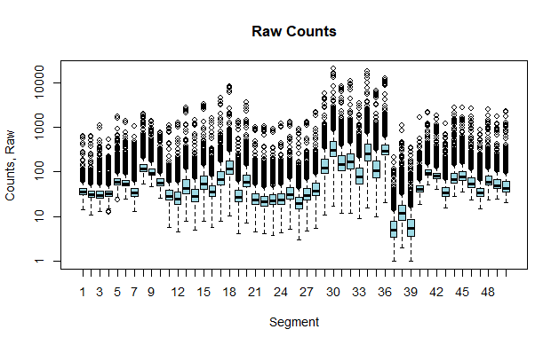

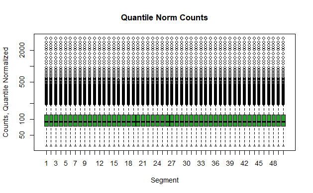

```r
compare_norm_plots <- function(GeoMxObj = all_q_norm){
  boxplot(exprs(GeoMxObj)[,1:50],
          col = "#9EDAE5", main = "Raw Counts",
          log = "y", names = 1:50, xlab = "Segment",
          ylab = "Counts, Raw")


  boxplot(assayDataElement(GeoMxObj[,1:50], elt = "q_norm"),
          col = "#2CA02C", main = "Quantile Norm Counts",
          log = "y", names = 1:50, xlab = "Segment",
          ylab = "Counts, Quantile Normalized")
}



compare_norm_plots(GeoMxObj = all_q_norm)
```

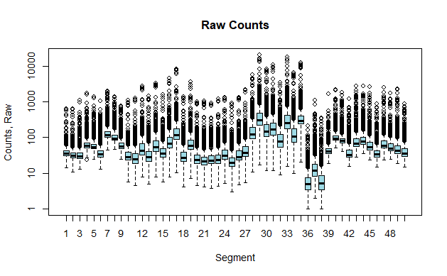

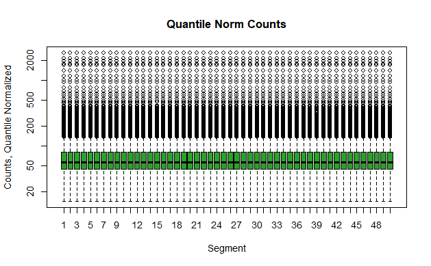

```r
compare_norm_plots(GeoMxObj = disc_q_norm)
```

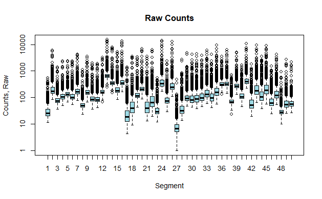

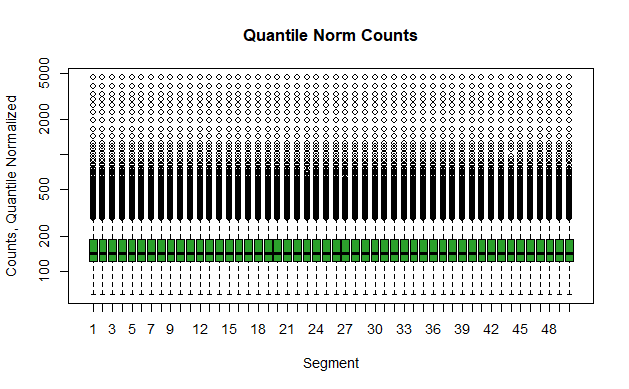

```r
compare_norm_plots(GeoMxObj = valid_q_norm)
```

# 6. Unsupervised Analysis

## 6.2 Clustering high CV Genes

Another approach to explore the data is to calculate the coefficient of variation (CV) for each gene (
$$g$$
) using the formula
$$CV_g=SD_g/mean_g$$
. We then identify genes with high CVs that should have large differences across the various profiled segments. This unbiased approach can reveal highly variable genes across the study.

```r
# library(pheatmap)
# assayDataElement(object = quantile_AnatCompData, elt = "log_q") <-
#     assayDataApply(quantile_AnatCompData, 2, FUN = log, base = 2, elt = "q_norm")
#
# # create CV function
# calc_CV <- function(x) {sd(x) / mean(x)}
# CV_dat <- assayDataApply(quantile_AnatCompData,
#                          elt = "log_q", MARGIN = 1, calc_CV)
# # show the highest CD genes and their CV values
# sort(CV_dat, decreasing = TRUE)[1:5]
# #>   CAMK2N1    AKR1C1      AQP2     GDF15       REN
# #> 0.5886006 0.5114973 0.4607206 0.4196469 0.4193216
#
# # Identify genes in the top 3rd of the CV values
# GOI <- names(CV_dat)[CV_dat > quantile(CV_dat, 0.8)]
# pheatmap(assayDataElement(quantile_AnatCompData[GOI, ], elt = "log_q"),
#          scale = "row",
#          show_rownames = FALSE, show_colnames = FALSE,
#          border_color = NA,
#          clustering_method = "average",
#          clustering_distance_rows = "correlation",
#          clustering_distance_cols = "correlation",
#          breaks = seq(-3, 3, 0.05),
#          color = colorRampPalette(c("red", "yellow2", "green3"))(120),
#          annotation_col =
#              pData(target_AnatCompData)[, c("Patient", "segment", "region")])
#
```